# Tugas Pertemuan 4

Widianto Sijabat

2026-09-16

# Pendahuluan

$n=300$ data

- **MA(2)** dengan $\theta_1=0.4$, $\theta_2=0.6$
- **AR(2)** dengan $\phi_1=0.5$, $\phi_2=0.2$
- **ARMA(2,2)** dengan $\phi_1=0.5$, $\phi_2=0.2$, $\theta_1=0.4$, $\theta_2=0.6$

Buat plot time series, plot ACF, plot PACF dan plot EACF. Idenifikasi apakah data tersebut stasioner

Buat scatterplot antara 𝑌𝑡 dengan 𝑌𝑡−1, 𝑌𝑡 dengan 𝑌𝑡−2 serta 𝑌𝑡 dengan 𝑌𝑡−3

Hitung autokorelasi masing masing baik dari data bangkitan maupun secara teoritis

## Fungsi EACF

```r
eacf <- function (z, ar.max = 7, ma.max = 13, plot_table = TRUE) {
  lag1 <- function(z, lag = 1) { c(rep(NA, lag), z[1:(length(z) - lag)]) }
  reupm <- function(m1, nrow, ncol) {
    k <- ncol - 1
    m2 <- NULL
    for (i in 1:k) {
      i1 <- i + 1
      work <- lag1(m1[, i])
      work[1] <- -1
      temp <- m1[, i1] - work * m1[i1, i1] / m1[i, i]
      temp[i1] <- 0
      m2 <- cbind(m2, temp)
    }
    m2
  }
  ceascf <- function(m, cov1, nar, ncol, count, ncov, z, zm) {
    result <- 0 * seq(1, nar + 1)
    result[1] <- cov1[ncov + count]
    for (i in 1:nar) {
      temp <- cbind(z[-(1:i)], zm[-(1:i), 1:i]) %*% c(1, -m[1:i, i])
      result[i + 1] <- acf(temp, plot = FALSE, lag.max = count, drop.lag.0 = FALSE)$acf[count + 1]
    }
    result
  }
  ar.max <- ar.max + 1
  ma.max <- ma.max + 1
  nar <- ar.max - 1
  nma <- ma.max
  ncov <- nar + nma + 2
  nrow <- nar + nma + 1
  ncol <- nrow - 1
  z <- z - mean(z)
  zm <- NULL
  for (i in 1:nar) zm <- cbind(zm, lag1(z, lag = i))
  cov1 <- acf(z, lag.max = ncov, plot = FALSE, drop.lag.0 = FALSE)$acf
  cov1 <- c(rev(cov1[-1]), cov1)
  ncov <- ncov + 1
  m1 <- matrix(0, ncol = ncol, nrow = nrow)
  for (i in 1:ncol) m1[1:i, i] <- ar.ols(z, order.max = i, aic = FALSE, demean = FALSE, intercept = FALSE)$ar
  eacfm <- NULL
  for (i in 1:nma) {
    m2 <- reupm(m1 = m1, nrow = nrow, ncol = ncol)
    ncol <- ncol - 1
    eacfm <- cbind(eacfm, ceascf(m2, cov1, nar, ncol, i, ncov, z, zm))
    m1 <- m2
  }
  work <- 1:(nar + 1)
  work <- length(z) - work + 1
  symbol <- NULL
  for (i in 1:nma) {
    work <- work - 1
    symbol <- cbind(symbol, ifelse(abs(eacfm[, i]) > 2 / work^.5, 'x', 'o'))
  }
  rownames(symbol) <- 0:(ar.max - 1)
  colnames(symbol) <- 0:(ma.max - 1)
  if (plot_table) {
    cat('AR/MA\n')
    print(symbol, quote = FALSE)
  }
  invisible(list(eacf = eacfm, ar.max = ar.max, ma.max = ma.max, symbol = symbol))
}

# Fungsi bantu: autokorelasi empiris pada lag k = 1,2,3
empirical_acf <- function(y, klags = 1:3) {
  sapply(klags, function(k) cor(y[-(1:k)], y[1:(length(y) - k)]))
}
```

# 1. Proses MA(2)

$$Y_t = e_t + \theta_1 e_{t-1} + \theta_2
e_{t-2}$$

dengan $\theta_1 = 0.4$ dan $\theta_2 = 0.6$.

## Pembangkitan Data

**Manual (loop):**

```r
theta1 <- 0.4
theta2 <- 0.6

set.seed(128)
wn <- rnorm(n)
ma2 <- numeric(n)
ma2[1] <- wn[1]
ma2[2] <- wn[2] + theta1 * wn[1]
for (i in 3:n) {
  ma2[i] <- wn[i] + theta1 * wn[i - 1] + theta2 * wn[i - 2]
}
head(ma2)
```

```
## [1] 0.5967718 0.7213207 2.2155131 0.9293338 2.1972719 1.0483656
```

**Dengan `arima.sim()`:**

```r
set.seed(128)
ma2.sim <- arima.sim(list(order = c(0, 0, 2), ma = c(theta1, theta2)), n = n)
head(ma2.sim)
```

```
## Time Series:
## Start = 1
## End = 6
## Frequency = 1
## [1] 2.2155131 0.9293338 2.1972719 1.0483656 0.4992118 0.1694259
```

## Plot Time Series

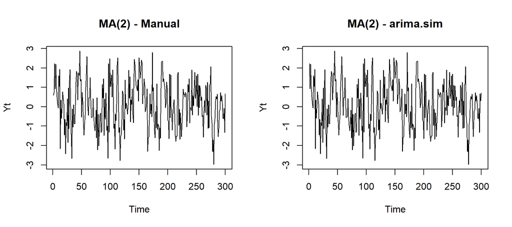

```r
par(mfrow = c(1, 2))
ts.plot(ma2, main = "MA(2) - Manual", ylab = "Yt")
ts.plot(ma2.sim, main = "MA(2) - arima.sim", ylab = "Yt")
```

```r
par(mfrow = c(1, 1))
```

Plot time series menunjukkan data berfluktuasi di sekitar nilai tengah nol tanpa tren maupun perubahan ragam yang sistematis

## Plot ACF

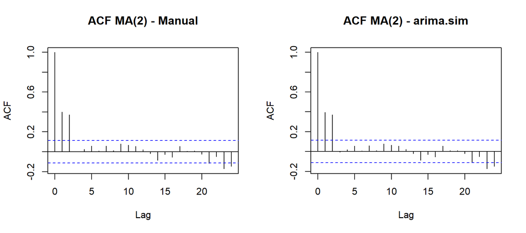

```r
par(mfrow = c(1, 2))
acf(ma2, main = "ACF MA(2) - Manual")
acf(ma2.sim, main = "ACF MA(2) - arima.sim")
```

```r
par(mfrow = c(1, 1))
```

ACF signifikan pada lag 1 dan lag 2, lalu terputus (cuts off) menuju nol pada lag $\ge 3$

## Plot PACF

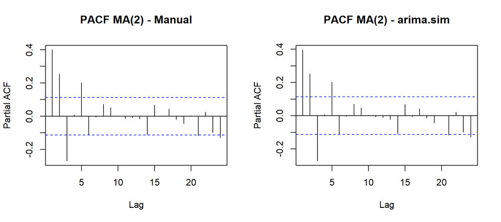

```r
par(mfrow = c(1, 2))
pacf(ma2, main = "PACF MA(2) - Manual")
pacf(ma2.sim, main = "PACF MA(2) - arima.sim")
```

```r
par(mfrow = c(1, 1))
```

PACF menurun bertahap menuju nol

## Plot EACF

```r
cat("EACF - Data Manual\n")
```

```
## EACF - Data Manual
```

```r
eacf(ma2, ar.max = 5, ma.max = 8)
```

```
## AR/MA
##   0 1 2 3 4 5 6 7 8
## 0 x x o o o o o o o
## 1 x x o o o o o o o
## 2 x x x o o o o o o
## 3 o x x x o o o o o
## 4 o x x x o o o o o
## 5 x x x x x o o o o
```

```r
cat("\nEACF - Data arima.sim\n")
```

```
##
## EACF - Data arima.sim
```

```r
eacf(ma2.sim, ar.max = 5, ma.max = 8)
```

```
## AR/MA
##   0 1 2 3 4 5 6 7 8
## 0 x x o o o o o o o
## 1 x x o o o o o o o
## 2 x x x o o o o o o
## 3 o x x x o o o o o
## 4 o x x x o o o o o
## 5 x x x x x o o o o
```

Segitiga nol (‘o’) mulai konsisten pada baris AR = 0, kolom MA $\ge 2$

### Kesimpulan kestasioneran:

berdasarkan plot time series, ACF (cuts off setelah lag 2), dan PACF (tails off), proses MA(2) stasioner

## Scatterplot Antar Lag

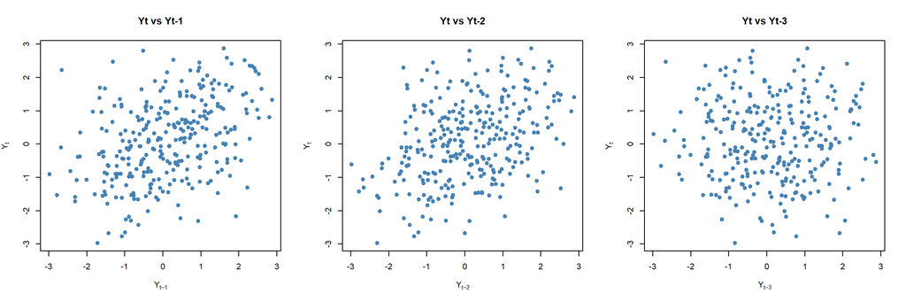

```r
par(mfrow = c(1, 3))
for (k in 1:3) {
  yt  <- ma2[-(1:k)]
  ytk <- ma2[1:(n - k)]
  plot(ytk, yt, xlab = bquote(Y[t - .(k)]), ylab = expression(Y[t]),
       main = paste0("Yt vs Yt-", k), pch = 19, col = "steelblue")
}
```

```r
par(mfrow = c(1, 1))
```

Scatterplot $Y_t$ vs $Y_{t-1}$ dan $Y_t$ vs $Y_{t-2}$ menunjukkan pola hubungan linear positif yang cukup jelas, sedangkan $Y_t$ vs $Y_{t-3}$ menunjukkan sebaran yang jauh lebih acak , konsisten dengan MA(2) yang hanya berkorelasi hingga lag ke-2.

## Autokorelasi: Empiris vs Teoritis

$$\rho_1 =
\frac{\theta_1+\theta_1\theta_2}{1+\theta_1^2+\theta_2^2}, \qquad \rho_2
= \frac{\theta_2}{1+\theta_1^2+\theta_2^2}, \qquad \rho_k = 0 \;
\text{untuk} \; k \ge 3$$

```r
emp_manual <- empirical_acf(ma2)
emp_sim    <- empirical_acf(ma2.sim)
theo_ma2   <- ARMAacf(ma = c(theta1, theta2), lag.max = 3)[2:4]

tabel_ma2 <- data.frame(
  Lag = 1:3,
  Empiris_Manual = round(emp_manual, 4),
  Empiris_arimasim = round(emp_sim, 4),
  Teoritis = round(theo_ma2, 4)
)
knitr::kable(tabel_ma2)
```

| Lag | Empiris_Manual | Empiris_arimasim | Teoritis |
| --- | --- | --- | --- |
| 1 | 0.3999 | 0.3989 | 0.4211 |
| 2 | 0.3740 | 0.3719 | 0.3947 |
| 3 | 0.0008 | -0.0051 | 0.0000 |

Nilai autokorelasi empiris mendekati nilai teoritis pada lag 1 dan 2, dan sama-sama mendekati nol pada lag 3

# 2. Proses AR(2)

$$Y_t = \phi_1 Y_{t-1} + \phi_2 Y_{t-2} +
e_t$$

dengan $\phi_1 = 0.5$ dan $\phi_2 = 0.2$.

## Pembangkitan Data

**Manual (loop):**

```r
phi1 <- 0.5
phi2 <- 0.2

set.seed(128)
wn2 <- rnorm(n)
ar2 <- numeric(n)
ar2[1] <- wn2[1]
ar2[2] <- phi1 * ar2[1] + wn2[2]
for (i in 3:n) {
  ar2[i] <- phi1 * ar2[i - 1] + phi2 * ar2[i - 2] + wn2[i]
}
head(ar2)
```

```
## [1] 0.5967718 0.7809979 2.1742586 1.2173333 2.2525453 1.9500915
```

**Dengan `arima.sim()`:**

```r
set.seed(128)
ar2.sim <- arima.sim(list(order = c(2, 0, 0), ar = c(phi1, phi2)), n = n)
head(ar2.sim)
```

```
## Time Series:
## Start = 1
## End = 6
## Frequency = 1
## [1] -2.4662302  0.2094559 -0.8214400  0.2697564  1.8916146 -0.1553783
```

## Plot Time Series

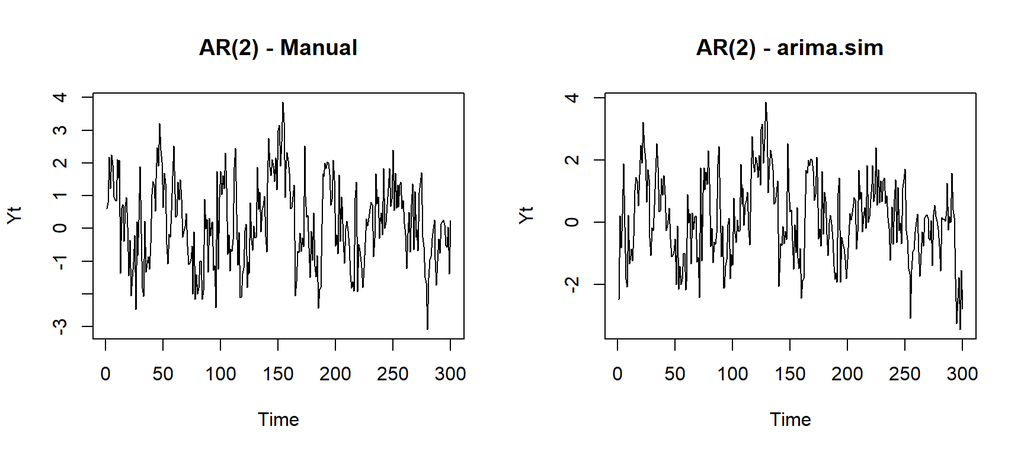

```r
par(mfrow = c(1, 2))
ts.plot(ar2, main = "AR(2) - Manual", ylab = "Yt")
ts.plot(ar2.sim, main = "AR(2) - arima.sim", ylab = "Yt")
```

```r
par(mfrow = c(1, 1))
```

Data berosilasi di sekitar nol dengan ragam relatif konstan, tanpa tren

## Plot ACF

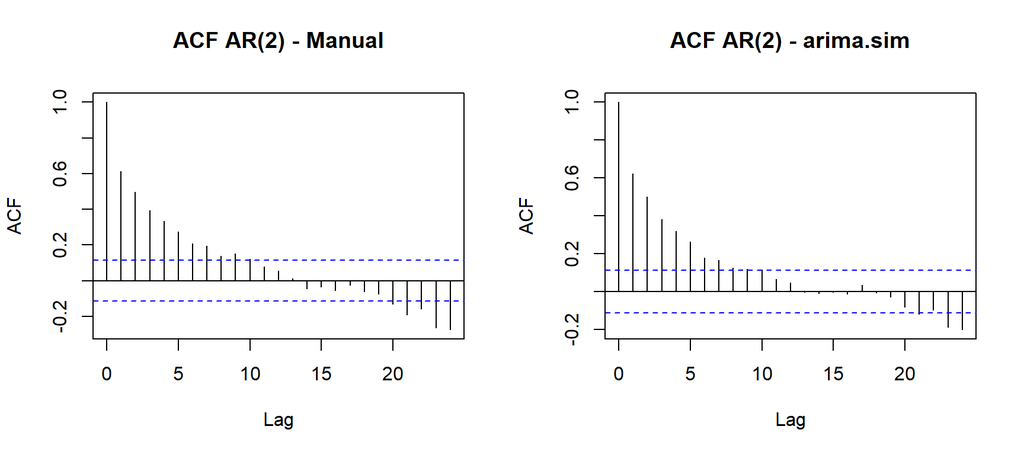

```r
par(mfrow = c(1, 2))
acf(ar2, main = "ACF AR(2) - Manual")
acf(ar2.sim, main = "ACF AR(2) - arima.sim")
```

```r
par(mfrow = c(1, 1))
```

ACF menurun secara bertahap/eksponensial menuju nol

## Plot PACF

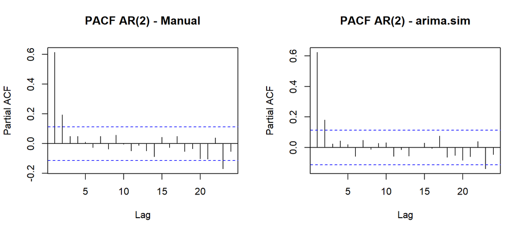

```r
par(mfrow = c(1, 2))
pacf(ar2, main = "PACF AR(2) - Manual")
pacf(ar2.sim, main = "PACF AR(2) - arima.sim")
```

```r
par(mfrow = c(1, 1))
```

PACF signifikan pada lag 1 dan 2, lalu **terputus (cuts off)** untuk lag $\ge 3$

## Plot EACF

```r
cat("EACF - Data Manual\n")
```

```
## EACF - Data Manual
```

```r
eacf(ar2, ar.max = 5, ma.max = 8)
```

```
## AR/MA
##   0 1 2 3 4 5 6 7 8
## 0 x x x x x x x x x
## 1 x o o o o o o o o
## 2 x x o o o o o o o
## 3 x x x o o o o o o
## 4 x x x o o o o o o
## 5 x o x o o o o o o
```

```r
cat("\nEACF - Data arima.sim\n")
```

```
##
## EACF - Data arima.sim
```

```r
eacf(ar2.sim, ar.max = 5, ma.max = 8)
```

```
## AR/MA
##   0 1 2 3 4 5 6 7 8
## 0 x x x x x x x x x
## 1 x o o o o o o o o
## 2 x o o o o o o o o
## 3 x x x o o o o o o
## 4 x x x o o o o o o
## 5 x x o o o o o o o
```

### Kesimpulan kestasioneran:

berdasarkan plot time series, ACF (tails off), dan PACF (cuts off setelah lag 2), proses AR(2) **stasioner**.

## Scatterplot Antar Lag

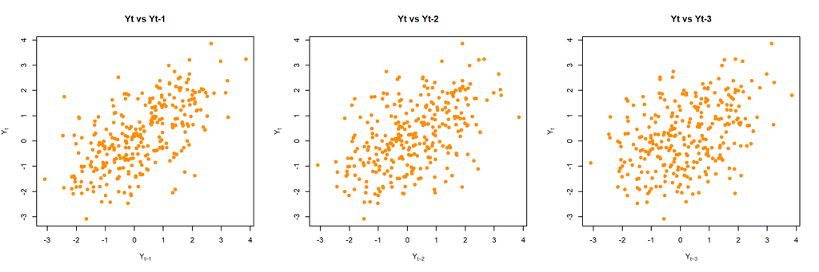

```r
par(mfrow = c(1, 3))
for (k in 1:3) {
  yt  <- ar2[-(1:k)]
  ytk <- ar2[1:(n - k)]
  plot(ytk, yt, xlab = bquote(Y[t - .(k)]), ylab = expression(Y[t]),
       main = paste0("Yt vs Yt-", k), pch = 19, col = "darkorange")
}
```

```r
par(mfrow = c(1, 1))
```

Ketiga scatterplot menunjukkan pola hubungan linear positif, dengan kekuatan hubungan yang melemah bertahap seiring bertambahnya lag

## Autokorelasi: Empiris vs Teoritis

$$\rho_1 = \frac{\phi_1}{1-\phi_2}, \qquad
\rho_k = \phi_1\rho_{k-1}+\phi_2\rho_{k-2} \; \text{untuk} \; k \ge
2$$

```r
emp_manual_ar <- empirical_acf(ar2)
emp_sim_ar    <- empirical_acf(ar2.sim)
theo_ar2      <- ARMAacf(ar = c(phi1, phi2), lag.max = 3)[2:4]

tabel_ar2 <- data.frame(
  Lag = 1:3,
  Empiris_Manual = round(emp_manual_ar, 4),
  Empiris_arimasim = round(emp_sim_ar, 4),
  Teoritis = round(theo_ar2, 4)
)
knitr::kable(tabel_ar2)
```

| Lag | Empiris_Manual | Empiris_arimasim | Teoritis |
| --- | --- | --- | --- |
| 1 | 0.6129 | 0.6328 | 0.6250 |
| 2 | 0.4976 | 0.5083 | 0.5125 |
| 3 | 0.3954 | 0.3939 | 0.3812 |

Nilai autokorelasi empiris cukup dekat dengan nilai teoritis pada lag 1-3

# 3. Proses ARMA(2,2)

Proses ARMA(2,2) didefinisikan sebagai:

$$Y_t = \phi_1 Y_{t-1} + \phi_2 Y_{t-2} +
e_t + \theta_1 e_{t-1} + \theta_2 e_{t-2}$$

dengan $\phi_1=0.5$, $\phi_2=0.2$, $\theta_1=0.4$, $\theta_2=0.6$.

## Pembangkitan Data

**Manual (loop):**

```r
set.seed(128)
wn3 <- rnorm(n)
arma22 <- numeric(n)
arma22[1] <- wn3[1]
arma22[2] <- phi1 * arma22[1] + wn3[2] + theta1 * wn3[1]
for (i in 3:n) {
  arma22[i] <- phi1 * arma22[i - 1] + phi2 * arma22[i - 2] +
    wn3[i] + theta1 * wn3[i - 1] + theta2 * wn3[i - 2]
}
head(arma22)
```

```
## [1] 0.5967718 1.0197066 2.8447208 2.5556355 4.0440338 3.5815097
```

**Dengan `arima.sim()`:**

```r
set.seed(128)
arma22.sim <- arima.sim(list(order = c(2, 0, 2), ar = c(phi1, phi2), ma = c(theta1, theta2)), n = n)
head(arma22.sim)
```

```
## Time Series:
## Start = 1
## End = 6
## Frequency = 1
## [1] -2.21815100  0.06627823  1.50621425  0.76278678 -0.74328322 -2.89324829
```

## Plot Time Series

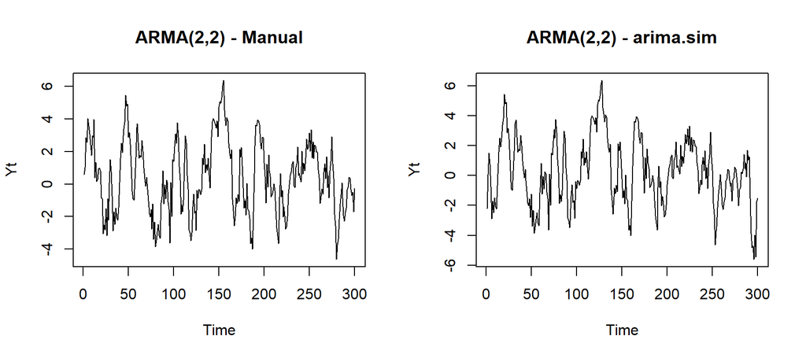

```r
par(mfrow = c(1, 2))
ts.plot(arma22, main = "ARMA(2,2) - Manual", ylab = "Yt")
ts.plot(arma22.sim, main = "ARMA(2,2) - arima.sim", ylab = "Yt")
```

```r
par(mfrow = c(1, 1))
```

Data berosilasi di sekitar nol dengan ragam stabil, tanpa tren

## Plot ACF

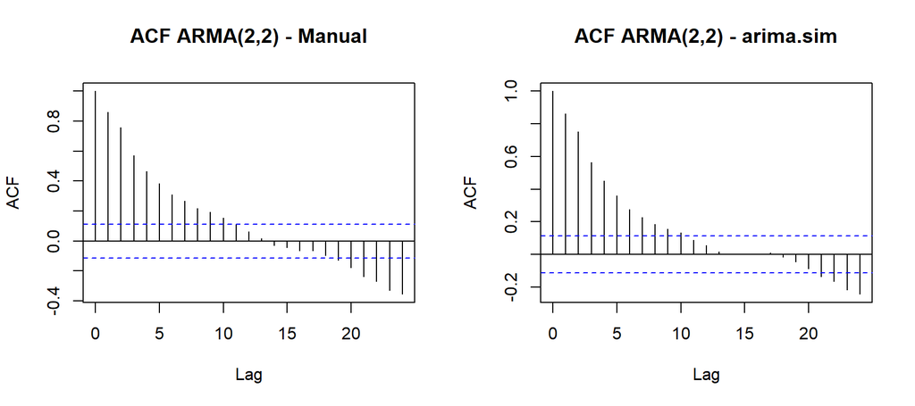

```r
par(mfrow = c(1, 2))
acf(arma22, main = "ACF ARMA(2,2) - Manual")
acf(arma22.sim, main = "ACF ARMA(2,2) - arima.sim")
```

```r
par(mfrow = c(1, 1))
```

ACF menurun bertahap menuju nol

## Plot PACF

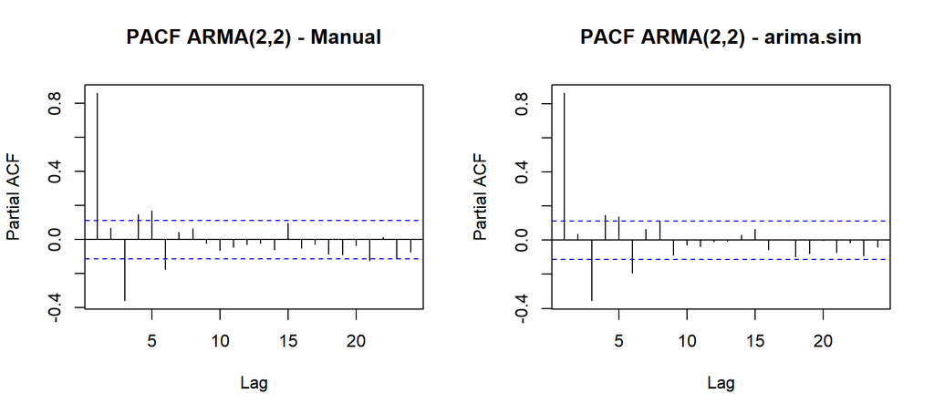

```r
par(mfrow = c(1, 2))
pacf(arma22, main = "PACF ARMA(2,2) - Manual")
pacf(arma22.sim, main = "PACF ARMA(2,2) - arima.sim")
```

```r
par(mfrow = c(1, 1))
```

PACF menurun bertahap menuju nol

## Plot EACF

```r
cat("EACF - Data Manual\n")
```

```
## EACF - Data Manual
```

```r
eacf(arma22, ar.max = 5, ma.max = 8)
```

```
## AR/MA
##   0 1 2 3 4 5 6 7 8
## 0 x x x x x x x x x
## 1 o x x o o o o o o
## 2 x x x o o o o o o
## 3 x x o o o o o o o
## 4 x x o x o o o o o
## 5 x x x x o o o o o
```

```r
cat("\nEACF - Data arima.sim\n")
```

```
##
## EACF - Data arima.sim
```

```r
eacf(arma22.sim, ar.max = 5, ma.max = 8)
```

```
## AR/MA
##   0 1 2 3 4 5 6 7 8
## 0 x x x x x x x x x
## 1 o x x o o o o o o
## 2 o x x o o o o o o
## 3 x x x o o o o o o
## 4 x x x o o x o o o
## 5 x x x o x o o o o
```

### Kesimpulan kestasioneran:

berdasarkan plot time series serta ACF & PACF yang sama-sama tails off, proses ARMA(2,2) stasioner dan dapat diasumsikan invertible

## Scatterplot Antar Lag

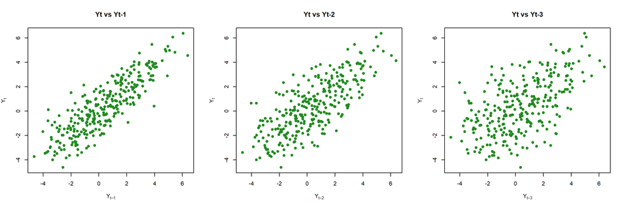

```r
par(mfrow = c(1, 3))
for (k in 1:3) {
  yt  <- arma22[-(1:k)]
  ytk <- arma22[1:(n - k)]
  plot(ytk, yt, xlab = bquote(Y[t - .(k)]), ylab = expression(Y[t]),
       main = paste0("Yt vs Yt-", k), pch = 19, col = "forestgreen")
}
```

```r
par(mfrow = c(1, 1))
```

Ketiganya menunjukkan pola hubungan linear positif yang kuat, dengan kekuatan hubungan menurun bertahap seiring bertambahnya lag

## Autokorelasi: Empiris vs Teoritis

```r
emp_manual_arma <- empirical_acf(arma22)
emp_sim_arma    <- empirical_acf(arma22.sim)
theo_arma22     <- ARMAacf(ar = c(phi1, phi2), ma = c(theta1, theta2), lag.max = 3)[2:4]

tabel_arma22 <- data.frame(
  Lag = 1:3,
  Empiris_Manual = round(emp_manual_arma, 4),
  Empiris_arimasim = round(emp_sim_arma, 4),
  Teoritis = round(theo_arma22, 4)
)
knitr::kable(tabel_arma22)
```

| Lag | Empiris_Manual | Empiris_arimasim | Teoritis |
| --- | --- | --- | --- |
| 1 | 0.8596 | 0.8639 | 0.8592 |
| 2 | 0.7580 | 0.7545 | 0.7492 |
| 3 | 0.5738 | 0.5724 | 0.5464 |

Nilai autokorelasi empiris konsisten satu sama lain dan searah dengan nilai teoritis, dengan pola meluruh

# 4.Kesimpulan

Ketiga proses (MA(2), AR(2), ARMA(2,2)) yang dibangkitkan dengan $n=300$ data terbukti stasioner berdasarkan plot time series, ACF, dan PACF-nya. Pola identifikasi ordo melalui ACF/PACF/EACF sesuai teori:

- **MA(2)**: ACF *cuts off* setelah lag 2, PACF *tails off*.
- **AR(2)**: ACF *tails off*, PACF *cuts off* setelah lag 2.
- **ARMA(2,2)**: ACF dan PACF sama-sama *tails off*.

Nilai autokorelasi empiris dari data bangkitan secara konsisten mendekati nilai autokorelasi teoritis pada setiap proses, menunjukkan bahwa pembangkitan data manual di R berhasil merepresentasikan model AR/MA/ARMA yang diinginkan dengan tepat.